# Bootstrap for testing similarity between two GMM’s.

Zeinab Mousavi

Bootstrap replications of a test statistic of interest for Hypothesis testing on GMMs.

### Description

Inputs $X$ and $Y$ are two independent observed random samples drawn from two unknown populations with probability distributions of $F$ and $G$, respectively. For simplicity, we assume each population has a Gaussian Mixture Model distribution with variance 1. As a two-sample problem, we test the hypothesis that

Ho: $F=G$ via Helligner_distance(F, G) = 0 (test statistic)

Ha: $F \neq G$ via Helligner_distance(F, G) > 0 (test statistic)

The bootstrap framework follows [BootStrap_SingleGaussian](https://docs.neurodata.io/graph-testing/Code/R/Bootstrap_SingleGaussian.html)

### Inputs:

$x_i \in R$ for $i \in {1, ..., n_{1}}$ observed samples from $F$

$y_i \in R$ for $i \in {1, ..., n_{2}}$ observed samples from $G$

### Assumptions:

$F$ ~ $\pi_x * N(\mu_{x_{1}}, \sigma^{2}) + (1-\pi_x)* N(\mu_{x_{2}}, \sigma^{2})$

$G$ ~ $\pi_y * N(\mu_{y_{1}}, \sigma^{2}) + (1-\pi_y)* N(\mu_{y_{2}}, \sigma^{2})$

$\sigma^{2}$ = 1

### Outputs:

p-value for observed graph statistic, scalar

power of the test, scalar

### Notation:

Hellinger distance of P and Q is denoted as $\Delta(P, Q)$

### Function:

Evaluate parameters of observed datasets under the alternative distribution via Expectation Maximization algorithm (MLE)

Fit to distribution under Ha

1a. $\hat{\mu}_{x_{1}}, \hat{\mu}_{x_{2}},\hat{\pi}_{x}, = argmax (L({\mu}_{x_{1}}, {\mu}_{x_{2}},{\pi}_{x};X))$

1b. $\hat{\mu}_{y_{1}}, \hat{\mu}_{y_{2}},\hat{\pi}_{y}, = argmax (L({\mu}_{y_{1}}, {\mu}_{y_{2}},{\pi}_{y};Y))$

Compute observed test statistic

2. $\hat\delta_{obs} = \Delta(X, Y)$

Evaluate parameters of observed datasets under the null distribution via Expectation Maximization algorithm (MLE)

Fit to distribution under Ho

3a. $Z = [X, Y]$

3b. $\hat{\mu}_{z_{1}}, \hat{\mu}_{z_{2}},\hat{\pi}_{z}, = argmax (L({\mu}_{z_{1}}, {\mu}_{z_{2}},{\pi}_{z};X))$

4. Construct bootstrap samples under the null hypothesis

for b = {1, .., B}:

$\tilde{x}^{b}_{i}$ ~ $\hat\pi_z * N(\hat\mu_{z_{1}}, \sigma^{2}) + (1-\hat\pi_z)* N(\hat\mu_{z_{2}}, \sigma^{2})$ for $i \in {1, ..., n_{1}}$

$\tilde{y}^{b}_{i}$ ~ $\hat\pi_z * N(\hat\mu_{z_{1}}, \sigma^{2}) + (1-\hat\pi_z)* N(\hat\mu_{z_{2}}, \sigma^{2})$ for $i \in {1, ..., n_{2}}$

Evaluate test statistic on bootstrapped dataset

$\hat\delta^{b} = \Delta(\tilde{X}^{b}, \tilde{Y}^{b})$

end

Compute p-value

5. p-value = $\frac{count(\hat\delta^{b} \geq \hat\delta_{obs})}{B}$

Find critical value for $\alpha$ = 0.05

6. $\hat\delta_{c}$ = quantile $( \hat\delta^{b}, .95)$

### Power of Test

Construct bootstrap samples under the alternative hypothesis

8. for b = {1, .., B}:

${x}^{b}_{i}$ ~ $\hat\pi_x * N(\hat\mu_{x_{1}}, \sigma^{2}) + (1-\hat\pi_x)* N(\hat\mu_{x_{2}}, \sigma^{2})$ for $i \in {1, ..., n_{1}}$

${y}^{b}_{i}$ ~ $\hat\pi_y * N(\hat\mu_{y_{1}}, \sigma^{2}) + (1-\hat\pi_y)* N(\hat\mu_{y_{2}}, \sigma^{2})$ for $i \in {1, ..., n_{2}}$

Evaluate test statistic on each bootstrapped dataset

$\hat\delta^{b} = \Delta({X}^{b}, {Y}^{b})$

end

Compute Power

9. Power = $\frac{count(\hat\delta^{b} \geq \hat\delta_{c})}{B}$

```r
require(distrEx)
require(mixtools)
```

Function to evaluate Hellinger Distance

```r
###HELLINGER DISTANCE####
Hellinger_Dist <- function(d1, d2){
  min_d1 = min(hist(d1, plot=FALSE)$breaks)
  max_d1 = max(hist(d1, plot=FALSE)$breaks)
  bin_width_d1 = mean(diff((hist(d1, plot=FALSE)$breaks)))
  min_d2 = min(hist(d2, plot=FALSE)$breaks)
  max_d2 = max(hist(d2, plot=FALSE)$breaks)
  bin_width_d2 = mean(diff((hist(d2, plot=FALSE)$breaks)))

  bin_width = min(bin_width_d1, bin_width_d2)
  min_break = min(min_d1, min_d2)
  max_break = max(max_d1, max_d2)
  h_breaks = seq(min_break, max_break, bin_width)
  h1 = hist(d1, breaks=h_breaks, plot=FALSE)
  h2 = hist(d2, breaks=h_breaks, plot=FALSE)
  p<- h1$density * diff(h1$breaks)
  q<- h2$density * diff(h2$breaks)
  Dist <- 1/sqrt(2)*sqrt(sum((sqrt(p)-sqrt(q))^2))
  return(Dist)
}
```

### Simulations

Two datasets, with size n, will be simulated by uniform sampling of two Gaussian Mixture Model distributions.

When the difference between the means of the two Gaussians is not zero, such as 0.1, we expect the Null Hypothesis to be rejected, p_value <0.05. We also expect the power of the test to inrease as sample size increases.

```r
GMM_sd <- c(1, 1)
GMM0_lambda <- c(0.3, 0.7)
GMM0_mean <- c(1, 8)
GMM1_lambda <-  c(0.3, 0.7)
GMM1_mean <-  c(1.1, 8.1)

k<-0
alpha = 0.05
n <- seq(1000, 7000, 1000)


power_boot <- c()

for (n_sample in n){
  ts_critical_null <- c()
  p_value <- c()
  #observed data
  set.seed(1)
  GMM_0 = rnormmix(n=n_sample, lambda=GMM0_lambda, mu=GMM0_mean, sigma=GMM_sd)
  set.seed(1)
  GMM_1 = rnormmix(n=n_sample, lambda=GMM1_lambda, mu=GMM1_mean, sigma=GMM_sd)
  ts_data <- Hellinger_Dist(GMM_0, GMM_1)

  #Estimate Parameters of Eachdataset
  GMM_0_EM = normalmixEM(GMM_0, k=2, maxit=1000, sigma=c(1, 1))
  GMM_0_lambda_estimate <- GMM_0_EM$lambda
  GMM_0_mean_estimate <- GMM_0_EM$mu

  GMM_1_EM = normalmixEM(GMM_1, k=2, maxit=1000, sigma=c(1, 1))
  GMM_1_lambda_estimate <- GMM_1_EM$lambda
  GMM_1_mean_estimate <- GMM_1_EM$mu

  #Estimate Paramaters of Null Distribution
  GMM_null <- c(GMM_0, GMM_1)
  GMM_null_EM = normalmixEM(GMM_null, k=2, maxit=1000, sigma=c(1, 1))
  GMM_null_lambda_estimate <- GMM_null_EM$lambda
  GMM_null_mean_estimate <- GMM_null_EM$mu

  #Now generate Bootstrap Samples

  ts_null <- c()
  ts_alt <- c()
  boot_strap <-1000
  for (b in seq(1, boot_strap, 1)){
    #generate from parameter estiamtes
    set.seed(b)
    GMM_0_boot <- rnormmix(n=n_sample, lambda=GMM_null_lambda_estimate, mu=GMM_null_mean_estimate, sigma=GMM_sd)
    GMM_1_boot <- rnormmix(n=n_sample, lambda=GMM_null_lambda_estimate, mu=GMM_null_mean_estimate, sigma=GMM_sd)

    ts_null[b] <- Hellinger_Dist(GMM_1_boot, GMM_0_boot)

  }

  k <- k+1
  ts_critical_null <- quantile(ts_null , 0.95)[[1]]
  p_value[k] <- sum(ts_null>ts_data)/boot_strap


  #Alternate Distrbution Bootstrap


  ts_null <- c()
  ts_alt <- c()
  boot_strap <-1000
  for (b in seq(1, boot_strap, 1)){
    #generate from parameter estiamtes
    set.seed(b)
    GMM_0_boot_alt <- rnormmix(n=n_sample, lambda=GMM_0_lambda_estimate, mu=GMM_0_mean_estimate, sigma=GMM_sd)
    GMM_1_boot_alt <- rnormmix(n=n_sample, lambda=GMM_1_lambda_estimate, mu=GMM_1_mean_estimate, sigma=GMM_sd)
    ts_alt[b] <- Hellinger_Dist(GMM_1_boot_alt, GMM_0_boot_alt)
  }

power_boot[k] <- sum(ts_alt>ts_critical_null)/boot_strap


}
```

## Power Plot

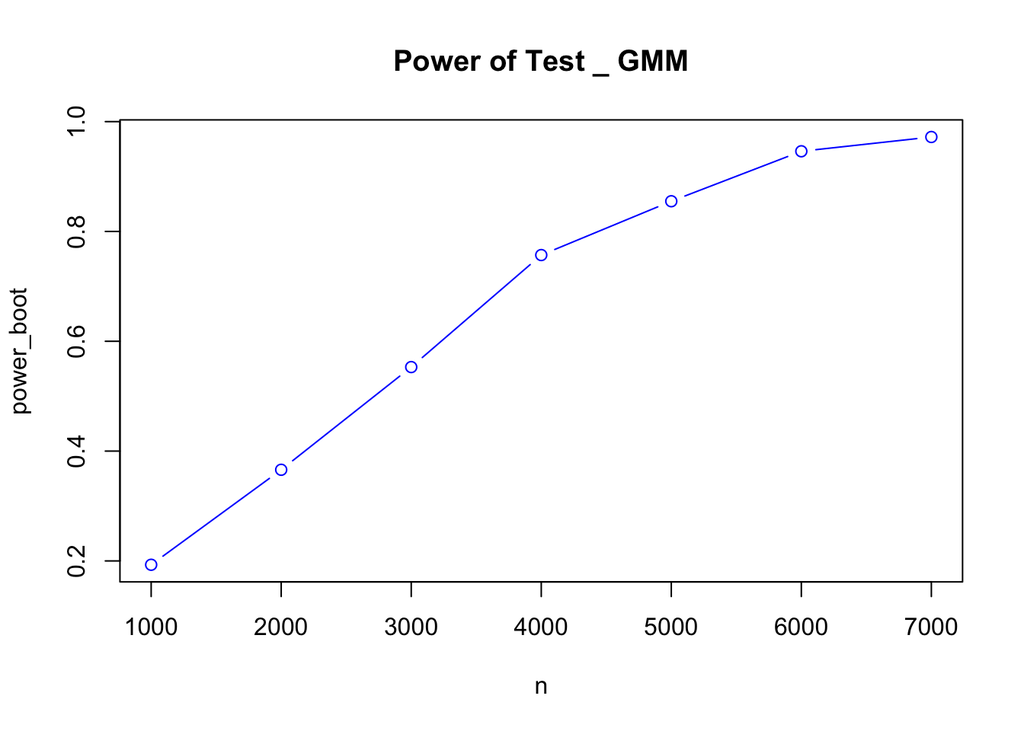

```r
plot(n, power_boot, type="b", col="blue", main = "Power of Test _ GMM")
```